# Reproducible Research: Peer Assessment 1

By default `echo = TRUE`, so don’t need to change it here.

## Load and preprocess the data

### Load necessary libraries:

```r
library(ggplot2)
library(dplyr)
library(knitr)
```

### Load data

After clone the repository, the data file activity.zip should be in the same directory as this RMarkdown script. Unzip the file:

```r
unzip(zipfile="./activity.zip")
```

Read in the csv file:

```r
activity <- read.csv("activity.csv",
                     header = TRUE,
                     sep = ',',
                     colClasses = c("numeric", "character", "integer"))
```

### Process data

Add datetime field to the dataset by combining date and interval

```r
activity <- transform(activity,
                      datetime = strptime(paste(date,
                              formatC(interval,
                                      width=4,
                                      flag="0")),
                              "%Y-%m-%d %H%M"))
```

## Mean total number of steps taken per day

### Calculate the total number of steps taken per day

```r
stepsPerDay <- aggregate(steps ~ date,
                         data = activity,
                         FUN = sum)
```

### Histogram of the total number of steps taken each day

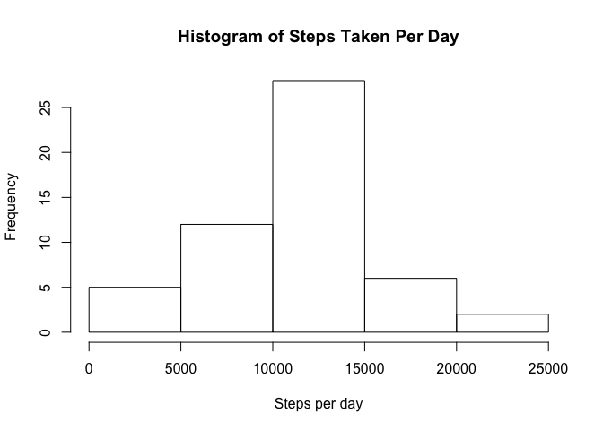

```r
hist(suppressWarnings(as.integer(unlist(stepsPerDay))),
     xlab = "Steps per day",
     ylab = "Frequency",
     main = "Histogram of Steps Taken Per Day")
```

### Calculate and report the mean and median of the total number of steps taken per day

Mean steps taken per day:

```r
meanStepsPerDay <- mean(stepsPerDay$steps,
                        na.rm = TRUE)
meanStepsPerDay
```

```
## [1] 10766.19
```

Median steps taken per day:

```r
medianStepsPerDay <- median(stepsPerDay$steps,
                            na.rm = TRUE)
medianStepsPerDay
```

```
## [1] 10765
```

## Average daily activity pattern

### Average daily steps

Calculate average steps per interval:

```r
stepsPerInterval <- aggregate(steps ~ interval,
                              data = activity,
                              FUN = mean)
```

Plot average steps per interval:

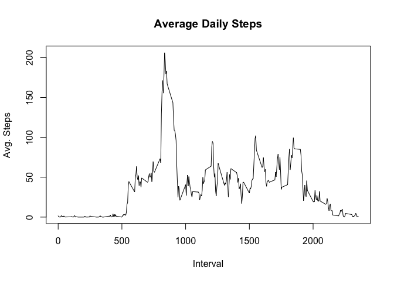

```r
plot(stepsPerInterval$interval,
     stepsPerInterval$steps,
     type = "l",
     xlab = "Interval",
     ylab = "Avg. Steps",
     main = "Average Daily Steps")
```

### 5-minute interval that contains the maximum number of steps

Find out which 5-minute interval, on average across all the days in the dataset, contains the maximum number of steps

```r
stepsPerInterval[which.max(stepsPerInterval$steps), ]
```

```
##     interval    steps
## 104      835 206.1698
```

Interval #835 has the maximum number of steps of about 206.

## Imputing missing values

### Total number of missing values

Calculate and report the total number of missing values in the dataset (i.e. the total number of rows with NAs)

```r
sum(is.na(activity$steps))
```

```
## [1] 2304
```

### Fill in missing values using the mean for same 5-minute interval

Join the activity data with the stepsPerInterval that was calculated earlier:

```r
filledActivity <- inner_join(activity,
                             stepsPerInterval,
                             by="interval")
```

Create a new dataset that is equal to the original dataset but with the missing data filled in. Fill in missing values with the means for same 5-minute interval, and make the new dataset `filledActivity`

```r
for (i in 1:nrow(filledActivity)) {
    if (is.na(filledActivity$steps.x[i])) {
        filledActivity$steps.x[i] <- filledActivity$steps.y[i]
    }
}
```

### Histogram of the total number of steps taken each day

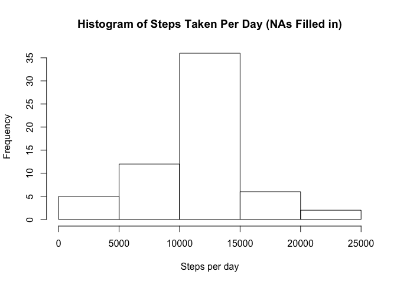

```r
stepsPerDayFilled <- aggregate(steps.x ~ date,
                               data = filledActivity,
                               FUN = sum)
hist(suppressWarnings(as.integer(unlist(stepsPerDayFilled))),
     xlab = "Steps per day",
     ylab = "Frequency",
     main = "Histogram of Steps Taken Per Day (NAs Filled in)")
```

### Mean and median total number of steps taken per day

Calculate and report the mean and median total number of steps taken per day

```r
meanStepsPerDayFilled <- mean(stepsPerDayFilled$steps.x,
                              na.rm = TRUE)
meanStepsPerDayFilled
```

```
## [1] 10766.19
```

Median steps taken per day:

```r
medianStepsPerDayFilled <- median(stepsPerDayFilled$steps.x,
                                  na.rm = TRUE)
medianStepsPerDayFilled
```

```
## [1] 10766.19
```

### Comparison

After filling in missing numbers, the mean steps per day stayed same as 10766.19, but median steps per day has increased from 10765 to 10766.19.

| Values | Original Dataset | New Dataset (Filled in NAs) |
| --- | --- | --- |
| Mean steps per day | 10766.19 | 10766.19 |
| Median steps per day | 10765 | 10766.19 |

After imputing missing data, the total daily number of steps has increased:

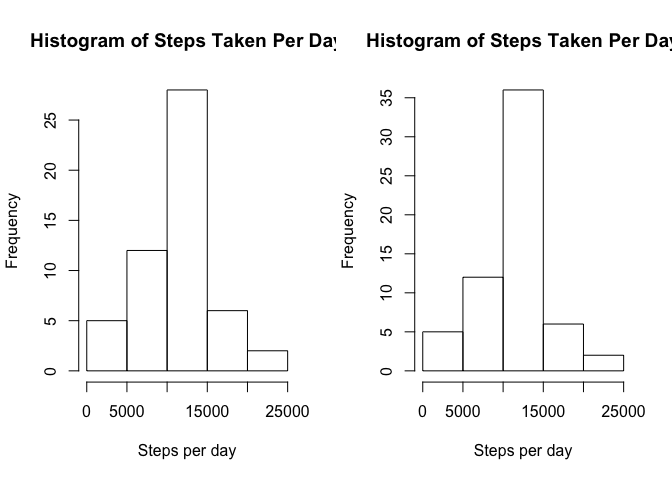

```r
par(mfrow = c(1, 2))
hist(suppressWarnings(as.integer(unlist(stepsPerDay))),
     xlab = "Steps per day",
     ylab = "Frequency",
     main = "Histogram of Steps Taken Per Day")
hist(suppressWarnings(as.integer(unlist(stepsPerDayFilled))),
     xlab = "Steps per day",
     ylab = "Frequency",
     main = "Histogram of Steps Taken Per Day")
```

## Differences in activity patterns between weekdays and weekends

Add a field `type` to the new dataset indicating if it’s a weekend or weekday:

```r
filledActivity <- mutate(filledActivity,
    type = ifelse(weekdays(filledActivity$datetime) == "Saturday"
        | weekdays(filledActivity$datetime) == "Sunday", "weekend", "weekday"))
```

Plot the average number of steps per 5-minute interval for weekend vs. weekday:

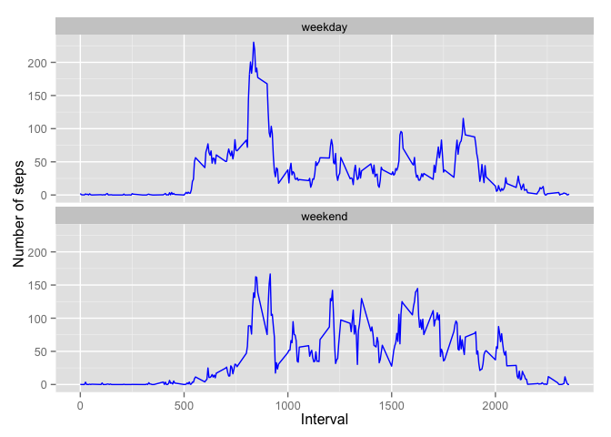

```r
avgSteps <- aggregate(steps.x ~ interval + type,
                      data = filledActivity,
                      mean)

ggplot(avgSteps, aes(interval, steps.x)) +
    geom_line(color = 'blue') +
    facet_wrap(~type, ncol = 1, nrow = 2) +
    xlab("Interval") +
    ylab("Number of steps")
```